# Poke-Stats Analysis Summer2026

```
Axes(0.125,0.11;0.775x0.77)
Axes(0.125,0.11;0.775x0.77)
```

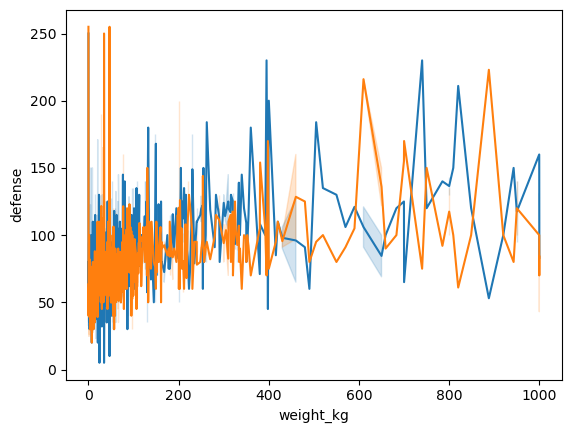

```python
line_defvswei = sns.lineplot(data=df, x='weight_kg', y='defense')
print(line_defvswei)
line_hpvswei = sns.lineplot(data=df, x='weight_kg', y='hp')
print(line_hpvswei)
```

## Weight vs HP/Defense. I hypothesized that the weight affected the defense/hp numbers in that a higher weight meant higher defense/hp because the Pokémon was bulkier. From the line chart, we can see that it's pretty much randomized, with the line spiking up and down constantly. This can be caused because of the material of the pokemon. A small, metal one is obviously heavier than a huge one made of feathers.

```python
df['types'] = df['type_1'] + '/' + df['type_2'].fillna('')
pd.set_option('display.max_rows', None)
print(df['types'].value_counts())
```

```
types
Normal/              86
Water/               84
Electric/            56
Grass/               49
Psychic/             48
Fire/                38
Fighting/            32
Normal/Flying        31
Fairy/               24
Bug/                 23
Ice/                 22
Rock/                20
Ghost/               19
Ground/              18
Rock/Flying          18
Dark/                17
Grass/Poison         17
Poison/              17
Bug/Flying           15
Steel/               14
Dragon/              14
Bug/Poison           13
Ghost/Grass          11
Dragon/Ground        10
Water/Ground         10
Water/Dark           10
Psychic/Fairy        10
Psychic/Flying        9
Grass/Dragon          9
Fire/Fighting         8
Electric/Flying       8
Bug/Steel             8
Steel/Psychic         8
Electric/Dragon       8
Fire/Flying           8
Water/Psychic         8
Steel/Dragon          7
Grass/Flying          7
Dark/Flying           7
```

[output cut: 168 more lines]

```
Dragon/Fire           1
Dragon/Electric       1
Normal/Ground         1
Fire/Water            1
Fire/Dark             1
Water/Steel           1
Bug/Dark              1
Flying/Dark           1
Dragon/Normal         1
Flying/Fighting       1
Ground/Fighting       1
Fairy/Psychic         1
Electric/Ground       1
Grass/Rock            1
Name: count, dtype: int64
```

## Type Combo Frequencies. I hypothesized that if types worked well against each other (held no weaknesses), they would show up more. And vice versa. My hypothesis was correct, as types like fire/water and fighting/ground are very rare. This is because they heavily conflict with each other. It could also be design-wise; it's hard to create a Pokémon with two completely opposite aesthetics.

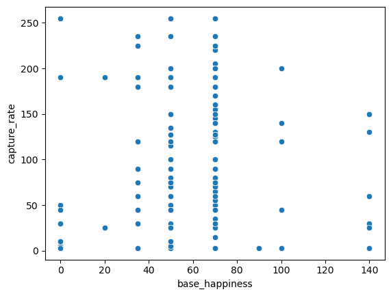

```python
sns.scatterplot(data=df, x='base_happiness', y='capture_rate')
plt.show()
```

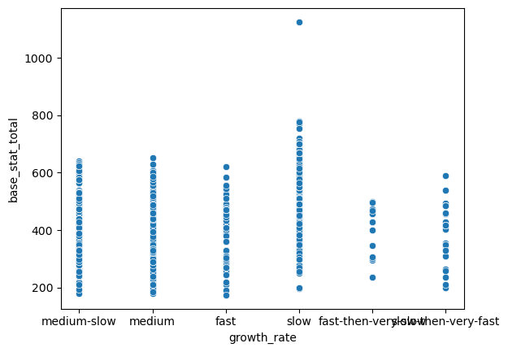

```python
sns.scatterplot(data=df, x='growth_rate', y='base_stat_total')
plt.show()
```